# Hypothesis Testing II

## Example 6

```r
cor.test(alzheimer_healthy$age, alzheimer_healthy$hippo)
```

```
    Pearson's product-moment correlation

data:  alzheimer_healthy$age and alzheimer_healthy$hippo
t = -15.125, df = 1532, p-value < 2.2e-16
alternative hypothesis: true correlation is not equal to 0
95 percent confidence interval:
 -0.4032192 -0.3160971
sample estimates:
      cor
-0.360444
```

```r
#alternatively, we can use linear regression
summary(lm(alzheimer_healthy$hippo ~ alzheimer_healthy$age))
```

```
Call:
lm(formula = alzheimer_healthy$hippo ~ alzheimer_healthy$age)

Residuals:
     Min       1Q   Median       3Q      Max
-2.57311 -0.48368 -0.01818  0.49369  2.80738

Coefficients:
                      Estimate Std. Error t value Pr(>|t|)
(Intercept)            8.00629    0.10570   75.75   <2e-16 ***
alzheimer_healthy$age -0.02329    0.00154  -15.12   <2e-16 ***
---
Signif. codes:  0 '***' 0.001 '**' 0.01 '*' 0.05 '.' 0.1 ' ' 1

Residual standard error: 0.7209 on 1532 degrees of freedom
Multiple R-squared:  0.1299,    Adjusted R-squared:  0.1294
F-statistic: 228.8 on 1 and 1532 DF,  p-value: < 2.2e-16
```

## Example 7

- **Research Question**: Does left hippocampal volume differ across diagnostic groups?
- **Null Hypothesis**:
- **Alternative Hypothesis**:

$$H_0: \mu_0=\mu_1=\mu_2 \mbox{ vs } H_1: \mbox{ at least two means are different}$$

- Method: one-way analysis of variance (ANOVA), more generally, linear regression

## Example 7

```r
ggplot(data= alzheimer_data,
       mapping= aes(x= diagnosis,
                    y=lhippo,
                    fill=diagnosis)) +
  geom_boxplot()+
  labs(
    title="Boxplot of lhippo by Diagnosis",
    x="Diagnosis",
    y="LHippo volume (cm^3)") +
  theme_minimal()
```

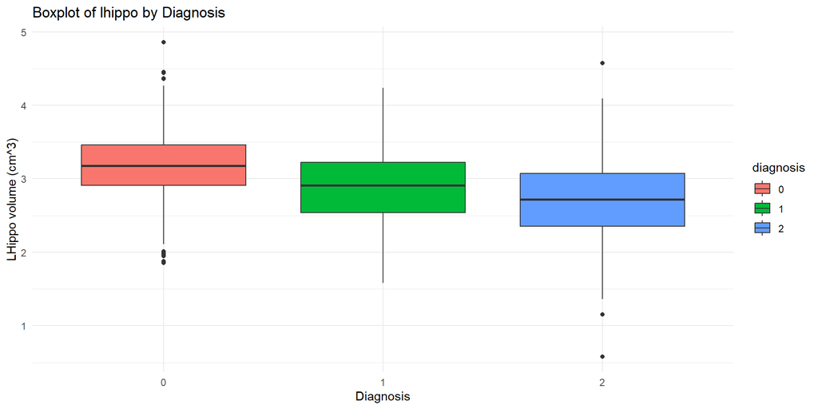

```r
summary(aov(alzheimer_data$lhippo ~ alzheimer_data$diagnosis))
```

```
                           Df Sum Sq Mean Sq F value Pr(>F)
alzheimer_data$diagnosis    2  100.5   50.27   247.1 <2e-16 ***
Residuals                2697  548.6    0.20
---
Signif. codes:  0 '***' 0.001 '**' 0.01 '*' 0.05 '.' 0.1 ' ' 1
```

```r
#equivalently
summary(aov(lhippo ~ diagnosis, data=alzheimer_data))
```

```
              Df Sum Sq Mean Sq F value Pr(>F)
diagnosis      2  100.5   50.27   247.1 <2e-16 ***
Residuals   2697  548.6    0.20
---
Signif. codes:  0 '***' 0.001 '**' 0.01 '*' 0.05 '.' 0.1 ' ' 1
```

## Summary

- Ex 1. Is the hippocampal volume of healthy males greater than 6 cm$^3$? (one-sample t-test)
- Ex 2. Is the proportion of healthy adults with a right hippocampal volume > 3cm$^3$ equal to 50%? (one-sample proportion test or z-test)
- Ex 3. Do healthy men and women have the same mean left hippocampal volume? (two-sample t-test)
- Ex 4. Is the left hippocampal volume equal to the right hippocampal volume in humans? (paired t-test)
- Ex 5. Is having a large hippocampus (> 7 cm$^3$) associated with gender? (chi-squared test)
- Ex 6. Is hippocampal volume correlated with age in healthy adults? (Pearson’s correlation or linear regression)
- Ex 7. Does left hippocampal volume differ across diagnostic groups? (one-way ANOVA or linear regression)